# Notebook_Capstone_CPI_DA_SDG_8_A

```python
#IMPORT LIBRARY

import pandas as pd
import numpy as np
import seaborn as sns
import matplotlib.pyplot as plt
```

## **Bacaan**

**Jonathan Calvin Limawal**

**Artikel 1**

Berdasarkan artikel "*GENDER WAGE GAP IN INDONESIA: GLASS CEILING OR STICKY FLOOR?*" (Hennigusnia, 2017), ditemukan:

- Pada tahun 2010-2012, persentase rata-rata kesenjangan upah antara perempuan dan laki- laki adalah lebih dari seratus persen.
- Di mana laki-laki memiliki upah lebih banyak (dengan perbedaan 100%) dibandingkan perempuan.
- Artinya, jika tanpa adanya diskriminasi maka perempuan akan memperoleh upah yang lebih tinggi dari pada laki-laki.

**Artikel 2**

Berdasarkan publikasi dan infografis dari **UN Women** pada September 2020 (https://asiapacific.unwomen.org/en/digital-library/publications/2020/09/infographic-gender-pay-gaps-in-indonesia), ditemukan:

- Di Indonesia, rata-rata perempuan berpenghasilan 23% lebih rendah dibandingkan laki-laki
- Rata-rata penghasilan laki-laki per Februari 2020 sebanyak Rp3,184,084 sedangkan wanita sebanyak Rp2,454,023
- Di lihat dari jenjang pendidikan terakhir, perempuan tetap berpenghasilan jauh lebih rendah dibandingkan laki-laki di setiap level pendidikan terakhir yang dicapai.

**Artikel 3**

Berdasarkan studi mandiri yang berjudul "Diskriminasi Penyandang Disabilitas dalam Dunia Kerja" (Ilyasa, 2020), ditemukan:

- Pada data tahun 2018, terdapat kesenjangan upah antara penyandang disabilitas (PD) dan non-penyandang disabilitas (Non-PD)
- Di mana Non-PD memiliki upah lebih banyak dibandingkan PD
- Kesenjangan upah sangat signifikan pada PD dengan jenis kelamin perempuan jika dibandingkan dengan PD dengan jenis kelamin laki-laki
- Selain itu, ditemukan juga bahwa pendidikan berpengaruh positif terhadap upah yang diterima PD

**Nia Puspitasari**

**Artikel 1:**

Berdasarkan artikel (https://finance.detik.com/berita-ekonomi-bisnis/d-4010695/gaji-perempuan-lebih-tinggi-dari-laki-laki-di-sektor-ini) ditemukan:

Terdapat sektor-sektor tertentu di mana gaji karyawan perempuan cenderung lebih tinggi dibandingkan dengan gaji karyawan laki-laki(per Februari 2018). Informasi tersebut adalah sebagai berikut:

- Rata-rata upah buruh perempuan di kategori konstruksi sebesar Rp 2,91 juta dan laki-laki sebesar Rp 2,62 juta
- Kategori transportasi dan pergudangan gaji buruh perempuan sebesar Rp 3,80 juta per bulan dan laki-laki sebesar Rp 3,12 juta per bulan
- Kategori real estat gaji karyawan perempuan sebesar Rp 3,21 juta per bulan dan laki-laki sebesar Rp 3,04 juta per bulan

**Artikel 2:**

Berdasarkan artikel (https://www.cnbcindonesia.com/mymoney/20221107145741-72-385737/gaji-perempuan-di-sini-lebih-gede-dari-laki-laki-minat) ditemukan:

1. Terdapat sektor-sektor pekerjaan di Indonesia yang menawarkan gaji yang jauh lebih tinggi bagi kaum perempuan dibandingkan dengan kaum laki-laki per Agustus 2022. Beberapa sektor tersebut adalah:
- Sektor Pertambangan dan Penggalian: Menawarkan upah tertinggi bagi perempuan sekitar Rp 6,87 juta per bulan, sementara kaum laki-laki di sektor ini hanya menerima Rp 4,49 juta per bulan.
- Sektor Pengadaan Listrik dan Gas: Menawarkan upah tinggi kepada perempuan sebesar Rp 6,29 juta per bulan, sedangkan kaum laki-laki hanya menerima Rp 4,49 juta per bulan.
- Sektor Jasa Keuangan dan Asuransi: Gaji karyawan perempuan di sektor Pengadaan Listrik dan Gas lebih tinggi daripada gaji karyawan laki-laki di sektor Jasa Keuangan dan Asuransi yang mencapai Rp 5,18 juta per bulan.
1. Secara umum, perempuan masih menerima upah yang lebih rendah daripada laki-laki. Hal ini disebabkan oleh pandangan bahwa perempuan yang bekerja sering dianggap sebagai pekerja sampingan dari ibu rumah tangga, yang menjadi salah satu tantangan yang perlu diatasi.

**Artikel 3:**

Nuraeni, Y., & Suryono, I. L. (2021). Analisis Kesetaraan Gender Dalam Bidang Ketenagakerjaan Di Indonesia. Nakhoda: Jurnal Ilmu Pemerintahan, 20(1), 68-79.

- Terdapat sektor-sektor tertentu di Indonesia yang memberikan upah/gaji tertinggi, seperti sektor pertambangan, listrik, gas, air, dan sektor jasa keuangan. Namun, jumlah pekerja perempuan di sektor-sektor tersebut masih relatif sedikit dibandingkan pekerja laki-laki.
- Banyak perempuan di Indonesia bekerja di sektor informal dengan upah yang rendah, ketidakjelasan aturan kerja, dan kurangnya jaminan sosial.
- Pekerja perempuan seringkali memiliki keterbatasan dalam hal pendidikan, pengalaman, ketrampilan, dan peluang kerja, sehingga mereka cenderung bekerja pada pekerjaan dengan upah rendah.
- Kesenjangan gender di tempat kerja dapat terjadi karena faktor-faktor seperti stereotip gender, diskriminasi, perbedaan dalam pendidikan, pengalaman kerja, dan eksklusivitas dalam jenis pekerjaan tertentu yang dianggap kurang cocok bagi perempuan.
- Beberapa daerah di Indonesia masih menganut konsep patriarki dan memiliki tuntutan sosial yang kuat terhadap perempuan untuk fokus pada peran sebagai pengasuh anak dan pengurus keluarga. Hal ini dapat menghambat partisipasi perempuan di pasar kerja.

**Artikel 4:**

Berdasarkan artikel (https://databoks.katadata.co.id/datapublish/2022/04/11/upah-laki-laki-lebih-tinggi-43-dari-perempuan-dalam-usaha-jasa) ditemukan:

- Pekerja laki-laki secara rata-rata memperoleh upah yang 43% lebih tinggi daripada pekerja perempuan di bidang jasa per 2021.
- Disusul oleh tenaga profesional, teknisi, dan pekerja sejenis dengan kesenjangan 33,52%. Sedangkan tenaga usaha pertanian, perkebunan, peternakan, perikanan, kehutanan, dan perburuan juga mengalami kesenjangan yang cukup besar.
- Tidak semua jenis pekerjaan mengalami perbaikan dalam kesetaraan upah gender. Tenaga kepemimpinan dan ketatalaksanaan mengalami peningkatan kesenjangan upah dari 2,77% pada tahun 2020 menjadi 6,31% pada tahun 2021.
- Terdapat jenis pekerjaan lainnya yang mencatat kesenjangan upah gender yang bernilai negatif, yaitu -6,74% pada tahun 2021. Ini berarti dalam jenis pekerjaan ini, pekerja perempuan memperoleh upah lebih tinggi daripada pekerja laki-laki.

**Artikel 5:**

Berdasarkan (Nofiani, N. S., & Kasnawi, M. T. (2022). PARTISIPASI KERJA PENYANDANG DISABILITAS: KETERKAITAN FAKTOR INTERNAL DAN EKSTERNAL. Sosio Informa Vol.8 No. 01 Kesejahteraan Sosial) ditemukan:

- Partisipasi angkatan kerja disabilitas di Indonesia ditemukan mengalami kesenjangan salah satunya seperti jenis kelamin.
- Penyandang disabilitas laki-laki lebih banyak berpartisipasi dalam pasar tenaga kerja daripada penyandang disabilitas perempuan.
- Status disabilitas membuat timbulnya kesenjangan dengan pekerja nondisabilitas yang dapat dilihat salah satunya dari upah yang diterima. Pekerja disabilitas dengan upah di bawah 2 juta rupiah setiap bulannya.
- Berdasarkan data Badan Pusat Statistik, 2020 menunjukkan bahwa hampir sepertiga pekerja disabilitas di Indonesia hanya menerima upah di bawah 1 juta rupiah per bulan. Berbeda dengan pekerja non-disabilitas yang justru menerima upah lebih dari 2 juta, dengan persentase sebesar 55,12 persen
- Penyandang disabilitas di Indonesia lebih banyak ditemukan pada berjenis kelamin perempuan.

**Artikel 6:**

Berdasarkan (Putri, M. A. (2017). Dimensi Sosial Tenaga Kerja Penyandang Disabilitas Usaha Kecil Menengah (UKM)“Tiara Handicraft”. Jurnal Ilmiah Mahasiswa FEB, 6(1).) ditemukan:

- Ada perbedaan yang signifikan dalam upah tenaga kerja disabilitas berdasarkan jenis kelamin
- Perempuan yang menyandang disabilitas seringkali menerima upah yang lebih rendah dibandingkan dengan laki-laki yang menyandang disabilitas.
- Perempuan yang menyandang disabilitas seringkali berisiko berada dalam kondisi ekonomi yang lebih buruk dibandingkan dengan laki-laki yang menyandang disabilitas, yang berdampak pada upah mereka.

**Raafli**

**Artikel 1 :**

Berdasarkan artikel (https://www.bls.gov/careeroutlook/2015/article/wage-differences.htm) menyatakan beberapa alasan perbedaan upah :

- Credentials, Pekerja yang memiliki pendidikan lanjutan atau memiliki sertifikasi atau lisensi profesional mungkin memperoleh penghasilan lebih besar dibandingkan pekerja lain dalam pekerjaan yang sama yang tidak memiliki kredensial tersebut, terutama ketika kredensial tersebut dicari oleh pemberi kerja.
- Pengalaman dan skills, pekerja berpengalaman biasanya mendapat penghasilan lebih besar dibandingkan pekerja pemula. Pekerja yang memiliki keterampilan yang dibutuhkan juga dapat memperoleh penghasilan lebih banyak.
- Industri, Gaji kerja berbeda-beda menurut industri dan pemberi kerja.

**Artikel 2 :**

Berdasarkan Tan, W. (2021). Kondisi tenaga kerja penyandang disabilitas: tantangan dalam mewujudkan sustainable development goals. Jurnal RechtIdee, 16(1), 18-36. Ditemukan bahwa :

- Pelaksanaan pemenuhan hak bekerja bagi penyandang disabilitas mengalami peningkatan yang cukup baik dari tahun 2016 hingga 2020, namun tetap belum maksimal dan efektif
- Tingkat pendidikan penyandang disabilitas yang rendah, dimana 45,74% tidak pernah/tidak lulus SD.
- Pekerja penyandang disabilitas kebanyakan bekerja di sektor informal

**Artikel 3 :**

Berdasarkan Longhi, S. (2017). The disability pay gap. Preuzeto, 10, 2019. Ditemukan bahwa :

- Kesenjangan upah bagi laki-laki penyandang disabilitas dibandingkan dengan laki-laki non-penyandang disabilitas umumnya lebih besar dibandingkan kesenjangan upah yang setara bagi perempuan penyandang disabilitas dibandingkan dengan perempuan non-penyandang disabilitas.
- Rendahnya kualifikasi penyandang disabilitas, Hal ini mungkin disebabkan oleh adanya hambatan dan berkurangnya kesempatan dalam pendidikan

**Referensi artikel (David)**

1. Berdasarkan hasil publikasi Kementerian Ketenagakerjaan pada Ketenagakerjaan dalam Angka 2021, diketahui:
- Pada Februari 2021, penduduk yang bekerja jika dikelompokkan menurut level skill sesuai jenis pekerjaannya (kecuali pada jenis pekerjaan TNI/POLRI), mayoritas termasuk dalam kelompok semi-skilled, dimana jumlahnya mencapai 91,46 juta orang. Sedangkan, mereka yang termasuk dalam kelompok basic-skilled sebanyak 24,73 juta orang dan yang termasuk kelompok skilled sebanyak 14,32 juta orang
- Mengacu hasil Sakernas, diperoleh informasi bahwa adanya pandemi Covid19 telah berdampak pada penurunan rata-rata upah buruh/karyawan/pegawai di Indonesia. Pada Februari 2021, rata-rata upah buruh/karyawan/pegawai sebesar Rp2.860.630/bulan. Nilai tersebut lebih kecil dari rata-rata upah buruh/karyawan/pegawai pada Februari 2020 yang sebesar Rp 2.911.540/bulan. Dengan kata lain, pada Februari 2021 terjadi penurunan rata-rata upah buruh/karyawan/pegawai sebesar 1,75 persen dibanding Februari 2020.
- Secara umum, menurut jenis kelamin, rata-rata upah per bulan untuk buruh/karyawan/pegawai laki-laki lebih besar dibandingkan rata-rata upah per bulan untuk buruh/karyawan/pegawai perempuan. Rata-rata upah buruh/karyawan/pegawai laki-laki sebesar Rp 3.101.907/bulan, sedangkan untuk buruh/karyawan/pegawai perempuan sebesar Rp 2.437.727/bulan. Hampir pada semua jenjang pendidikan rata-rata upah per bulan untuk buruh/karyawan/pegawai laki-laki lebih besar dibandingkan rata-rata upah per bulan untuk buruh/karyawan/pegawai perempuan. Sehingga, dari data ini dapat diartikan bahwa dengan tingkat pendidikan yang sama, buruh/karyawan/pegawai laki-laki cenderung mendapatkan upah yang lebih besar dibanding buruh/karyawan/pegawai perempuan.

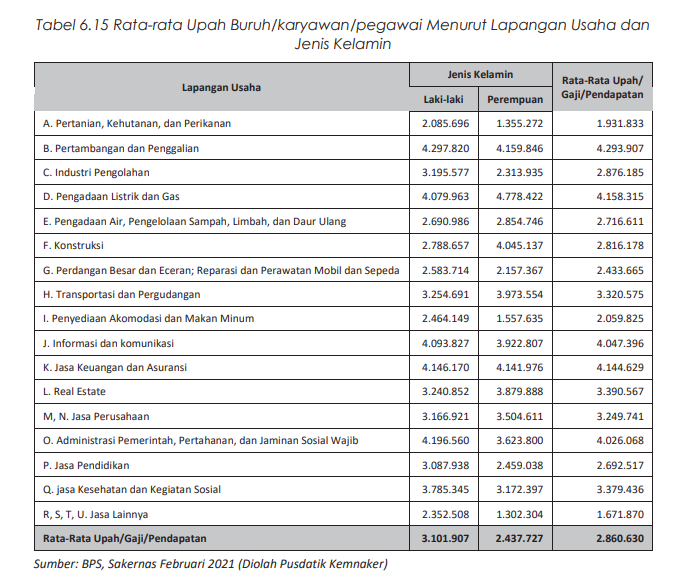

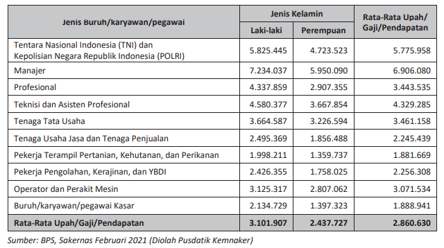

## **Hipotesis**

Bagian 1

1. Di kebanyakan provinsi, masyarakat Indonesia belum memiliki penghasilan (upah) yang cukup --> **DONE**
2. Sampai saat ini, masih ada kesenjangan penghasilan yang signifikan antara perempuan dan laki-laki di Indonesia --> **DONE**
3. Rata-rata perbedaan (kesenjangan) penghasilan antara laki-laki dan perempuan untuk beberapa tahun belakangan ini, masih berada di sekitar Rp700.000 --> **DONE**
4. Dengan tingkat pendidikan yang sama, laki-laki menerima upah lebih tinggi dibandingkan perempuan --> **DONE**
5. Pendidikan berpengaruh positif terhadap penghasilan yang diterima Penyandang Disablitas (PD) --> **??? Questionable - Can't be answered**
6. Ada faktor lain (selain pendidikan dan gender) yang mempengaruhi upah Penyandang Disablitas (PD)

Bagian 2

1. Kesenjangan upah berdasarkan gender di Indonesia dapat bervariasi berdasarkan sektor pekerjaan, dengan sektor tertentu yang memberikan upah lebih tinggi bagi perempuan dibandingkan laki-laki. **On Progress**
2. Terdapat faktor-faktor tertentu, seperti tingkat pendidikan, pengalaman kerja, dan jenis pekerjaan, yang dapat menjelaskan perbedaan dalam kesenjangan upah gender di berbagai sektor. --> **??? Questionable - Can't be answered**
3. Kesenjangan upah gender cenderung lebih besar di sektor-sektor yang didominasi oleh pekerja laki-laki, sementara sektor-sektor yang didominasi oleh pekerja perempuan cenderung memiliki kesenjangan yang lebih kecil. **On Progress**
4. Kesenjangan upah sangat signifikan pada PD dengan jenis kelamin perempuan jika dibandingkan dengan PD dengan jenis kelamin laki-laki **DONE**
5. Pekerja non-disabilitas di Indonesia cenderung memiliki upah yang lebih tinggi daripada pekerja disabilitas **DONE**

## Hypothesis 1

**In most provinces, Indonesians do not earn enough wage.**

Wage per Province Data (taken from SAKERNAS 2018, 2020, and 2022):

1. https://www.bps.go.id/publication/2018/11/30/6d8a8eb26ac657f7bd170fca/keadaan-angkatan-kerja-di-indonesia-agustus-2018.html
2. https://www.bps.go.id/publication/2022/12/07/a64afccf38fbf6deb81a5dc0/keadaan-angkatan-kerja-di-indonesia-agustus-2022.html
3. https://www.bps.go.id/publication/2020/11/30/307a288d678f91b9be362021/keadaan-angkatan-kerja-di-indonesia-agustus-2020.html

Minimum Wage (UMR) per Province Data (taken from Kemnaker):

1. https://satudata.kemnaker.go.id/data/kumpulan-data/36
2. https://satudata.kemnaker.go.id/data/kumpulan-data/473

```python
# Import and Show the Wage Data for Each Province in 2016-2022
url1 = 'https://raw.githubusercontent.com/JCalvinL19/CapstoneDAGigih/main/Data_Gaji_Provinsi.csv'
df1 = pd.read_csv(url1, sep =";")
df1.head()
```

|  | Provinsi | Tahun | Nilai |
| --- | --- | --- | --- |
| 0 | Aceh | 2022 | 2327990,41 |
| 1 | Sumatera Utara | 2022 | 2576441,62 |
| 2 | Sumatera Barat | 2022 | 2655766,93 |
| 3 | Riau | 2022 | 2889690,94 |
| 4 | Jambi | 2022 | 2520767,42 |

```python
# Counting the Number of Provinces
df1[df1['Provinsi'] != 'Indonesia']['Provinsi'].nunique()
```

```
34
```

```python
df1[df1['Provinsi'] != 'Indonesia']['Tahun'].value_counts()
```

```
2022    34
2021    34
2020    34
2019    34
2018    34
2017    34
2016    34
Name: Tahun, dtype: int64
```

> [Provinsi] means the province that include 34 provinces in Indonesia, [Tahun] means the year, and [Nilai] indicates the average wage of the residents of the respective province

```python
# Replacing the Comma into Dot for Each Values in Nilai Column
df1['Nilai'] = df1['Nilai'].str.replace(',', '.').astype(float)
df1['Nilai'].head()
```

```
0    2327990.41
1    2576441.62
2    2655766.93
3    2889690.94
4    2520767.42
Name: Nilai, dtype: float64
```

```python
# Showing some Informations about the Dataframe
df1.info()
```

```
<class 'pandas.core.frame.DataFrame'>
RangeIndex: 245 entries, 0 to 244
Data columns (total 3 columns):
 #   Column    Non-Null Count  Dtype
---  ------    --------------  -----
 0   Provinsi  245 non-null    object
 1   Tahun     245 non-null    int64
 2   Nilai     245 non-null    float64
dtypes: float64(1), int64(1), object(1)
memory usage: 5.9+ KB
```

```python
# Showing the Average Wage for All Provinces in 2016-2022
df1[df1['Provinsi'] == 'Indonesia']
```

|  | Provinsi | Tahun | Nilai |
| --- | --- | --- | --- |
| 34 | Indonesia | 2022 | 3070756.0 |
| 69 | Indonesia | 2021 | 2736462.0 |
| 104 | Indonesia | 2020 | 2756345.0 |
| 139 | Indonesia | 2019 | 2913896.0 |
| 174 | Indonesia | 2018 | 2829129.0 |
| 209 | Indonesia | 2017 | 2742621.0 |
| 244 | Indonesia | 2016 | 2552962.0 |

```python
# Import and Show the Provincial Minimum Wages Data in 2016-2022
url_ump = 'https://raw.githubusercontent.com/JCalvinL19/CapstoneDAGigih/main/Data_UMP.csv'
df_ump = pd.read_csv(url_ump, sep =";")
df_ump.head()
```

|  | Provinsi | Tahun | UMR/UMP |
| --- | --- | --- | --- |
| 0 | Aceh | 2016 | 2118500.0 |
| 1 | Sumatera Utara | 2016 | 1811875.0 |
| 2 | Sumatera Barat | 2016 | 1800725.0 |
| 3 | Riau | 2016 | 2095000.0 |
| 4 | Jambi | 2016 | 1906650.0 |

```python
# Show Some Informations about the Dataframe
df_ump.info()
```

```
<class 'pandas.core.frame.DataFrame'>
RangeIndex: 245 entries, 0 to 244
Data columns (total 3 columns):
 #   Column    Non-Null Count  Dtype
---  ------    --------------  -----
 0   Provinsi  245 non-null    object
 1   Tahun     245 non-null    int64
 2   UMR/UMP   242 non-null    float64
dtypes: float64(1), int64(1), object(1)
memory usage: 5.9+ KB
```

```python
df_ump['Provinsi'] = df_ump['Provinsi'].str.title()
df_ump.head()
df_ump[df_ump['Provinsi'] == 'Indonesia']
```

|  | Provinsi | Tahun | UMR/UMP |
| --- | --- | --- | --- |
| 34 | Indonesia | 2016 | NaN |
| 69 | Indonesia | 2017 | 2074151.0 |
| 104 | Indonesia | 2018 | 2268874.0 |
| 139 | Indonesia | 2019 | 2455662.0 |
| 174 | Indonesia | 2020 | 2672371.0 |
| 209 | Indonesia | 2021 | 2687724.0 |
| 244 | Indonesia | 2022 | 2725505.0 |

```python
df1[df1['Tahun'] == 2022].head(35)
```

|  | Provinsi | Tahun | Nilai |
| --- | --- | --- | --- |
| 0 | Aceh | 2022 | 2327990.41 |
| 1 | Sumatera Utara | 2022 | 2576441.62 |
| 2 | Sumatera Barat | 2022 | 2655766.93 |
| 3 | Riau | 2022 | 2889690.94 |
| 4 | Jambi | 2022 | 2520767.42 |
| 5 | Sumatera Selatan | 2022 | 2630695.17 |
| 6 | Bengkulu | 2022 | 2737834.17 |
| 7 | Lampung | 2022 | 2322727.62 |
| 8 | Kepulauan Bangka Belitung | 2022 | 2969145.83 |
| 9 | Kepulauan Riau | 2022 | 4155519.50 |
| 10 | DKI Jakarta | 2022 | 5255823.70 |
| 11 | Jawa Barat | 2022 | 3533612.79 |
| 12 | Jawa Tengah | 2022 | 2200715.85 |
| 13 | DI Yogyakarta | 2022 | 2462582.97 |
| 14 | Jawa Timur | 2022 | 2638751.60 |
| 15 | Banten | 2022 | 4370278.23 |
| 16 | Bali | 2022 | 3002534.18 |
| 17 | Nusa Tenggara Barat | 2022 | 2218413.70 |
| 18 | Nusa Tenggara Timur | 2022 | 2100927.48 |
| 19 | Kalimantan Barat | 2022 | 2645919.84 |
| 20 | Kalimantan Tengah | 2022 | 3195306.23 |
| 21 | Kalimantan Selatan | 2022 | 2898485.70 |
| 22 | Kalimantan Timur | 2022 | 3963731.50 |
| 23 | Kalimantan Utara | 2022 | 3427758.77 |
| 24 | Sulawesi Utara | 2022 | 3240216.75 |
| 25 | Sulawesi Tengah | 2022 | 2605724.08 |
| 26 | Sulawesi Selatan | 2022 | 2876951.59 |
| 27 | Sulawesi Tenggara | 2022 | 2831990.54 |
| 28 | Gorontalo | 2022 | 2551300.67 |
| 29 | Sulawesi Barat | 2022 | 2340501.68 |
| 30 | Maluku | 2022 | 2719294.46 |
| 31 | Maluku Utara | 2022 | 2938080.71 |
| 32 | Papua Barat | 2022 | 3283235.31 |
| 33 | Papua | 2022 | 3954382.41 |
| 34 | Indonesia | 2022 | 3070756.00 |

```python
df_ump['Provinsi'] = df_ump['Provinsi'].replace(['Di Yogyakarta', 'Dki Jakarta'], ['DI Yogyakarta', 'DKI Jakarta'])
df_ump[df_ump['Tahun'] == 2022]
```

|  | Provinsi | Tahun | UMR/UMP |
| --- | --- | --- | --- |
| 210 | Aceh | 2022 | 3166460.0 |
| 211 | Sumatera Utara | 2022 | 2522610.0 |
| 212 | Sumatera Barat | 2022 | 2512539.0 |
| 213 | Riau | 2022 | 2938564.0 |
| 214 | Jambi | 2022 | 2698941.0 |
| 215 | Sumatera Selatan | 2022 | 3144446.0 |
| 216 | Bengkulu | 2022 | 2238094.0 |
| 217 | Lampung | 2022 | 2440486.0 |
| 218 | Kepulauan Bangka Belitung | 2022 | 3264884.0 |
| 219 | Kepulauan Riau | 2022 | 3050172.0 |
| 220 | DKI Jakarta | 2022 | 4641854.0 |
| 221 | Jawa Barat | 2022 | 1841487.0 |
| 222 | Jawa Tengah | 2022 | 1812935.0 |
| 223 | DI Yogyakarta | 2022 | 1840916.0 |
| 224 | Jawa Timur | 2022 | 1891567.0 |
| 225 | Banten | 2022 | 2501203.0 |
| 226 | Bali | 2022 | 2516971.0 |
| 227 | Nusa Tenggara Barat | 2022 | 2207212.0 |
| 228 | Nusa Tenggara Timur | 2022 | 1975000.0 |
| 229 | Kalimantan Barat | 2022 | 2434328.0 |
| 230 | Kalimantan Tengah | 2022 | 2922516.0 |
| 231 | Kalimantan Selatan | 2022 | 2906473.0 |
| 232 | Kalimantan Timur | 2022 | 3014497.0 |
| 233 | Kalimantan Utara | 2022 | 3016738.0 |
| 234 | Sulawesi Utara | 2022 | 3310723.0 |
| 235 | Sulawesi Tengah | 2022 | 2390739.0 |
| 236 | Sulawesi Selatan | 2022 | 3165876.0 |
| 237 | Sulawesi Tenggara | 2022 | 2576017.0 |
| 238 | Gorontalo | 2022 | 2800580.0 |
| 239 | Sulawesi Barat | 2022 | 2678863.0 |
| 240 | Maluku | 2022 | 2619313.0 |
| 241 | Maluku Utara | 2022 | 2862231.0 |
| 242 | Papua Barat | 2022 | 3200000.0 |
| 243 | Papua | 2022 | 3561932.0 |
| 244 | Indonesia | 2022 | 2725505.0 |

```python
# Merge the Provincial Minimum Wage Data with the Average Wage Data in 2022
merged_data = pd.merge(df_ump, df1, on=['Provinsi', 'Tahun'])
merged_data = merged_data[merged_data['Tahun'] == 2022]
merged_data['Disparity'] = merged_data['Nilai'] - merged_data['UMR/UMP']
merged_data['Percentage of Disparity (%)'] = (merged_data['Disparity'] * 100) / merged_data['UMR/UMP']
merged_data
```

|  | Provinsi | Tahun | UMR/UMP | Nilai | Disparity | Percentage of Disparity (%) |
| --- | --- | --- | --- | --- | --- | --- |
| 210 | Aceh | 2022 | 3166460.0 | 2327990.41 | -838469.59 | -26.479715 |
| 211 | Sumatera Utara | 2022 | 2522610.0 | 2576441.62 | 53831.62 | 2.133965 |
| 212 | Sumatera Barat | 2022 | 2512539.0 | 2655766.93 | 143227.93 | 5.700526 |
| 213 | Riau | 2022 | 2938564.0 | 2889690.94 | -48873.06 | -1.663161 |
| 214 | Jambi | 2022 | 2698941.0 | 2520767.42 | -178173.58 | -6.601611 |
| 215 | Sumatera Selatan | 2022 | 3144446.0 | 2630695.17 | -513750.83 | -16.338358 |
| 216 | Bengkulu | 2022 | 2238094.0 | 2737834.17 | 499740.17 | 22.328828 |
| 217 | Lampung | 2022 | 2440486.0 | 2322727.62 | -117758.38 | -4.825202 |
| 218 | Kepulauan Bangka Belitung | 2022 | 3264884.0 | 2969145.83 | -295738.17 | -9.058152 |
| 219 | Kepulauan Riau | 2022 | 3050172.0 | 4155519.50 | 1105347.50 | 36.238858 |
| 220 | DKI Jakarta | 2022 | 4641854.0 | 5255823.70 | 613969.70 | 13.226821 |
| 221 | Jawa Barat | 2022 | 1841487.0 | 3533612.79 | 1692125.79 | 91.889098 |
| 222 | Jawa Tengah | 2022 | 1812935.0 | 2200715.85 | 387780.85 | 21.389672 |
| 223 | DI Yogyakarta | 2022 | 1840916.0 | 2462582.97 | 621666.97 | 33.769437 |
| 224 | Jawa Timur | 2022 | 1891567.0 | 2638751.60 | 747184.60 | 39.500827 |
| 225 | Banten | 2022 | 2501203.0 | 4370278.23 | 1869075.23 | 74.727051 |
| 226 | Bali | 2022 | 2516971.0 | 3002534.18 | 485563.18 | 19.291568 |
| 227 | Nusa Tenggara Barat | 2022 | 2207212.0 | 2218413.70 | 11201.70 | 0.507504 |
| 228 | Nusa Tenggara Timur | 2022 | 1975000.0 | 2100927.48 | 125927.48 | 6.376075 |
| 229 | Kalimantan Barat | 2022 | 2434328.0 | 2645919.84 | 211591.84 | 8.692002 |
| 230 | Kalimantan Tengah | 2022 | 2922516.0 | 3195306.23 | 272790.23 | 9.334089 |
| 231 | Kalimantan Selatan | 2022 | 2906473.0 | 2898485.70 | -7987.30 | -0.274811 |
| 232 | Kalimantan Timur | 2022 | 3014497.0 | 3963731.50 | 949234.50 | 31.488985 |
| 233 | Kalimantan Utara | 2022 | 3016738.0 | 3427758.77 | 411020.77 | 13.624676 |
| 234 | Sulawesi Utara | 2022 | 3310723.0 | 3240216.75 | -70506.25 | -2.129633 |
| 235 | Sulawesi Tengah | 2022 | 2390739.0 | 2605724.08 | 214985.08 | 8.992411 |
| 236 | Sulawesi Selatan | 2022 | 3165876.0 | 2876951.59 | -288924.41 | -9.126207 |
| 237 | Sulawesi Tenggara | 2022 | 2576017.0 | 2831990.54 | 255973.54 | 9.936795 |
| 238 | Gorontalo | 2022 | 2800580.0 | 2551300.67 | -249279.33 | -8.900989 |
| 239 | Sulawesi Barat | 2022 | 2678863.0 | 2340501.68 | -338361.32 | -12.630781 |
| 240 | Maluku | 2022 | 2619313.0 | 2719294.46 | 99981.46 | 3.817087 |
| 241 | Maluku Utara | 2022 | 2862231.0 | 2938080.71 | 75849.71 | 2.650021 |
| 242 | Papua Barat | 2022 | 3200000.0 | 3283235.31 | 83235.31 | 2.601103 |
| 243 | Papua | 2022 | 3561932.0 | 3954382.41 | 392450.41 | 11.017909 |
| 244 | Indonesia | 2022 | 2725505.0 | 3070756.00 | 345251.00 | 12.667414 |

```python
# Show the average of the wage and provincial minimum wage
wage_indonesia_2022 = df1[(df1['Provinsi'] == 'Indonesia') & (df1['Tahun'] == 2022)]['Nilai'].values
umr_indonesia_2022 = df_ump[(df_ump['Provinsi'] == 'Indonesia') & (df_ump['Tahun'] == 2022)]['UMR/UMP'].values
print("The average wage of all Indonesians in 2022 is", np.mean(wage_indonesia_2022))
print("The average provincial minimum wage in 2022 is", np.mean(umr_indonesia_2022))
```

```
The average wage of all Indonesians in 2022 is 3070756.0
The average provincial minimum wage in 2022 is 2725505.0
```

```python
# Filter the DataFrame where the wage is below UMP
provinces_below_minimum_wage = merged_data[(merged_data['Disparity'] < 0) & (merged_data['Provinsi'] != 'Indonesia')]

# Count the number of provinces where wage is less than minimum wage
count = len(provinces_below_minimum_wage)

# Print the count and list of provinces
print(f"Number of Provinces where Its Residents' Average Wage is Lower Than the Provincial Minimum Wage: {count}")
provinces_below_minimum_wage[['Provinsi', 'Disparity', 'Percentage of Disparity (%)']].sort_values(by = 'Percentage of Disparity (%)', ascending = False).reset_index(drop=True)
```

```
Number of Provinces where Its Residents' Average Wage is Lower Than the Provincial Minimum Wage: 11
```

|  | Provinsi | Disparity | Percentage of Disparity (%) |
| --- | --- | --- | --- |
| 0 | Kalimantan Selatan | -7987.30 | -0.274811 |
| 1 | Riau | -48873.06 | -1.663161 |
| 2 | Sulawesi Utara | -70506.25 | -2.129633 |
| 3 | Lampung | -117758.38 | -4.825202 |
| 4 | Jambi | -178173.58 | -6.601611 |
| 5 | Gorontalo | -249279.33 | -8.900989 |
| 6 | Kepulauan Bangka Belitung | -295738.17 | -9.058152 |
| 7 | Sulawesi Selatan | -288924.41 | -9.126207 |
| 8 | Sulawesi Barat | -338361.32 | -12.630781 |
| 9 | Sumatera Selatan | -513750.83 | -16.338358 |
| 10 | Aceh | -838469.59 | -26.479715 |

```python
# Filter the DataFrame where the wage is above UMP
provinces_above_minimum_wage = merged_data[(merged_data['Disparity'] > 0) & (merged_data['Provinsi'] != 'Indonesia')]

# Count the number of provinces where wage is less than minimum wage
count = len(provinces_above_minimum_wage)

# Print the count and list of provinces
print(f"Number of Provinces where Its Residents' Average Wage is Higher Than the Provincial Minimum Wage: {count}")
provinces_above_minimum_wage[['Provinsi', 'Disparity', 'Percentage of Disparity (%)']].sort_values(by = 'Percentage of Disparity (%)', ascending = False).reset_index(drop=True)
```

```
Number of Provinces where Its Residents' Average Wage is Higher Than the Provincial Minimum Wage: 23
```

|  | Provinsi | Disparity | Percentage of Disparity (%) |
| --- | --- | --- | --- |
| 0 | Jawa Barat | 1692125.79 | 91.889098 |
| 1 | Banten | 1869075.23 | 74.727051 |
| 2 | Jawa Timur | 747184.60 | 39.500827 |
| 3 | Kepulauan Riau | 1105347.50 | 36.238858 |
| 4 | DI Yogyakarta | 621666.97 | 33.769437 |
| 5 | Kalimantan Timur | 949234.50 | 31.488985 |
| 6 | Bengkulu | 499740.17 | 22.328828 |
| 7 | Jawa Tengah | 387780.85 | 21.389672 |
| 8 | Bali | 485563.18 | 19.291568 |
| 9 | Kalimantan Utara | 411020.77 | 13.624676 |
| 10 | DKI Jakarta | 613969.70 | 13.226821 |
| 11 | Papua | 392450.41 | 11.017909 |
| 12 | Sulawesi Tenggara | 255973.54 | 9.936795 |
| 13 | Kalimantan Tengah | 272790.23 | 9.334089 |
| 14 | Sulawesi Tengah | 214985.08 | 8.992411 |
| 15 | Kalimantan Barat | 211591.84 | 8.692002 |
| 16 | Nusa Tenggara Timur | 125927.48 | 6.376075 |
| 17 | Sumatera Barat | 143227.93 | 5.700526 |
| 18 | Maluku | 99981.46 | 3.817087 |
| 19 | Maluku Utara | 75849.71 | 2.650021 |
| 20 | Papua Barat | 83235.31 | 2.601103 |
| 21 | Sumatera Utara | 53831.62 | 2.133965 |
| 22 | Nusa Tenggara Barat | 11201.70 | 0.507504 |

## Hypothesis 2

Overall, **women** in Indonesia do not earn enough wages.

Source: https://bisnisman.nusaputra.ac.id/article/download/6/6/

Dataset: https://www.ilo.org/shinyapps/bulkexplorer43/?lang=en&id=EAR_4MTH_SEX_DSB_CUR_NB_A

```python
url2 = 'https://raw.githubusercontent.com/JCalvinL19/CapstoneDAGigih/main/Earnings_Sex%20and%20Disability%20Status.csv'
df2 = pd.read_csv(url2)
df2.head()
```

|  | Country | Source | Sex | Disability status | Currency | Year | Value |
| --- | --- | --- | --- | --- | --- | --- | --- |
| 0 | Indonesia | LFS - National Labour Force Survey | Total | Aggregate: Total | Currency: Local currency | 2022 | 2690034.7 |
| 1 | Indonesia | LFS - National Labour Force Survey | Total | Aggregate: Total | Currency: 2017 PPP $ | 2022 | 550.2 |
| 2 | Indonesia | LFS - National Labour Force Survey | Total | Aggregate: Total | Currency: U.S. dollars | 2022 | 181.2 |
| 3 | Indonesia | LFS - National Labour Force Survey | Total | Aggregate: Persons with disability | Currency: Local currency | 2022 | 2042223.5 |
| 4 | Indonesia | LFS - National Labour Force Survey | Total | Aggregate: Persons with disability | Currency: 2017 PPP $ | 2022 | 417.7 |

```python
# Filter dataset dengan kondisi Currency = Local Currency dan Disability Status = Total (Normal + Disabled)
local_currency_data = df2[(df2['Currency'] == 'Currency: Local currency') & (df2['Disability status'] == 'Aggregate: Total') ]

# Group BY Sex and Year
result = local_currency_data.groupby(['Sex', 'Year'])['Value'].sum().reset_index()
gender_earn = result.pivot(index='Year', columns='Sex', values='Value')
gender_earn
```

| Sex Year | Female | Male | Total |
| --- | --- | --- | --- |
| 2016 | 1830763.1 | 2271850.4 | 2125593.7 |
| 2017 | 2061855.9 | 2620257.9 | 2433700.8 |
| 2018 | 2083532.2 | 2658234.1 | 2465848.9 |
| 2019 | 2181905.7 | 2796506.3 | 2589312.7 |
| 2020 | 2186555.7 | 2752550.3 | 2561509.9 |
| 2021 | 2177332.3 | 2679556.8 | 2511508.1 |
| 2022 | 2269100.0 | 2895368.5 | 2690034.7 |

```python
df_ump_indo = df_ump[df_ump['Provinsi'] == 'Indonesia']
df_ump_indo
```

|  | Provinsi | Tahun | UMR/UMP |
| --- | --- | --- | --- |
| 34 | Indonesia | 2016 | NaN |
| 69 | Indonesia | 2017 | 2074151.0 |
| 104 | Indonesia | 2018 | 2268874.0 |
| 139 | Indonesia | 2019 | 2455662.0 |
| 174 | Indonesia | 2020 | 2672371.0 |
| 209 | Indonesia | 2021 | 2687724.0 |
| 244 | Indonesia | 2022 | 2725505.0 |

```python
# Membandingkan gaji (berdasarkan Gender) dengan UMR dari tahun ke tahun
df_ump_indo = df_ump_indo.dropna(subset=['UMR/UMP'])

# Merge the two DataFrames based on the 'Year' and 'Tahun' columns
merged_df = pd.merge(gender_earn, df_ump_indo, left_index=True, right_on='Tahun', how='inner')

# Create a new column based on the comparison
merged_df['UMR vs F'] = np.where(merged_df['UMR/UMP'] < merged_df['Female'], 'Di atas UMR', 'Di bawah UMR')
merged_df['UMR vs M'] = np.where(merged_df['UMR/UMP'] < merged_df['Male'], 'Di atas UMR', 'Di bawah UMR')

# Drop unnecessary columns
merged_df = merged_df.drop(['Provinsi', 'Total'], axis=1).reset_index(drop=True)
merged_df
```

|  | Female | Male | Tahun | UMR/UMP | UMR vs F | UMR vs M |
| --- | --- | --- | --- | --- | --- | --- |
| 0 | 2061855.9 | 2620257.9 | 2017 | 2074151.0 | Di bawah UMR | Di atas UMR |
| 1 | 2083532.2 | 2658234.1 | 2018 | 2268874.0 | Di bawah UMR | Di atas UMR |
| 2 | 2181905.7 | 2796506.3 | 2019 | 2455662.0 | Di bawah UMR | Di atas UMR |
| 3 | 2186555.7 | 2752550.3 | 2020 | 2672371.0 | Di bawah UMR | Di atas UMR |
| 4 | 2177332.3 | 2679556.8 | 2021 | 2687724.0 | Di bawah UMR | Di bawah UMR |
| 5 | 2269100.0 | 2895368.5 | 2022 | 2725505.0 | Di bawah UMR | Di atas UMR |

Kesimpulan:

- Jika dibandingkan dengan UMR se-Indonesia, dari tahun 2017 - 2022, rata-rata gaji (penghasilan) **perempuan** di Indonesia **selalu di bawah** UMR.
- Di sisi lain, rata-rata gaji (penghasilan) **laki-laki** di Indonesia **hampir selalu di atas** UMR dari tahun 2017 - 2022.
- Oleh karena itu, dapat disimpulkan bahwa rata-rata perempuan di Indonesia tidak memiliki gaji (penghasilan) yang cukup.

## Hypothesis 2.1

Until recently, there was still a significant wage gap between women and men in Indonesia

Source: https://ejurnal.kependudukan.lipi.go.id/index.php/jki/article/view/37

Dataset: https://www.ilo.org/shinyapps/bulkexplorer43/?lang=en&id=EAR_4MTH_SEX_DSB_CUR_NB_A

```python
# Load Dataset
url2_1 = 'https://raw.githubusercontent.com/JCalvinL19/CapstoneDAGigih/main/Earnings_Sex%20and%20Disability%20Status.csv'
df2_1 = pd.read_csv(url2_1)
df2_1.head()
```

|  | Country | Source | Sex | Disability status | Currency | Year | Value |
| --- | --- | --- | --- | --- | --- | --- | --- |
| 0 | Indonesia | LFS - National Labour Force Survey | Total | Aggregate: Total | Currency: Local currency | 2022 | 2690034.7 |
| 1 | Indonesia | LFS - National Labour Force Survey | Total | Aggregate: Total | Currency: 2017 PPP $ | 2022 | 550.2 |
| 2 | Indonesia | LFS - National Labour Force Survey | Total | Aggregate: Total | Currency: U.S. dollars | 2022 | 181.2 |
| 3 | Indonesia | LFS - National Labour Force Survey | Total | Aggregate: Persons with disability | Currency: Local currency | 2022 | 2042223.5 |
| 4 | Indonesia | LFS - National Labour Force Survey | Total | Aggregate: Persons with disability | Currency: 2017 PPP $ | 2022 | 417.7 |

```python
# Filter dataset dengan kondisi Currency = Local Currency dan Disabilit Statusy = Total (Normal + Disabled)
local_currency_data = df2_1[(df2_1['Currency'] == 'Currency: Local currency') & (df2_1['Disability status'] == 'Aggregate: Total') ]

# Group BY Sex and Year
result = local_currency_data.groupby(['Sex', 'Year'])['Value'].sum().reset_index()
result
```

|  | Sex | Year | Value |
| --- | --- | --- | --- |
| 0 | Female | 2016 | 1830763.1 |
| 1 | Female | 2017 | 2061855.9 |
| 2 | Female | 2018 | 2083532.2 |
| 3 | Female | 2019 | 2181905.7 |
| 4 | Female | 2020 | 2186555.7 |
| 5 | Female | 2021 | 2177332.3 |
| 6 | Female | 2022 | 2269100.0 |
| 7 | Male | 2016 | 2271850.4 |
| 8 | Male | 2017 | 2620257.9 |
| 9 | Male | 2018 | 2658234.1 |
| 10 | Male | 2019 | 2796506.3 |
| 11 | Male | 2020 | 2752550.3 |
| 12 | Male | 2021 | 2679556.8 |
| 13 | Male | 2022 | 2895368.5 |
| 14 | Total | 2016 | 2125593.7 |
| 15 | Total | 2017 | 2433700.8 |
| 16 | Total | 2018 | 2465848.9 |
| 17 | Total | 2019 | 2589312.7 |
| 18 | Total | 2020 | 2561509.9 |
| 19 | Total | 2021 | 2511508.1 |
| 20 | Total | 2022 | 2690034.7 |

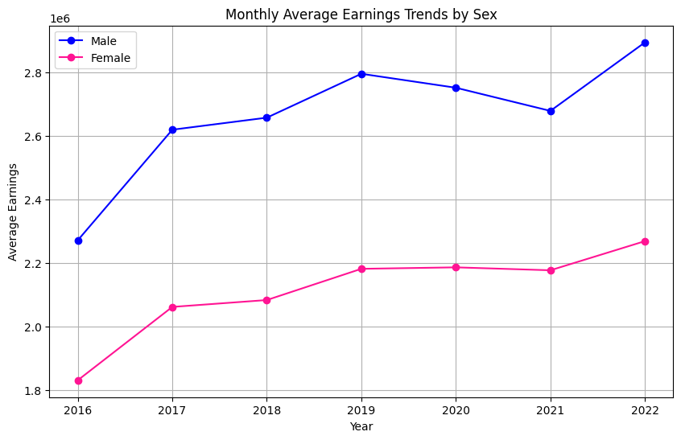

```python
import matplotlib.pyplot as plt

# Plot hasil Group By
pivot_result = result.pivot(index='Year', columns='Sex', values='Value')
plt.figure(figsize=(10, 6))
plt.plot(pivot_result['Male'], marker='o', color = 'blue', label='Male')
plt.plot(pivot_result['Female'], marker='o', color = 'deeppink', label='Female')
plt.xlabel('Year')
plt.ylabel('Average Earnings')
plt.title('Monthly Average Earnings Trends by Sex')
plt.legend()
plt.grid()
plt.show()
```

KESIMPULAN:

> Perbedaan penghasilan antara keduanya cenderung tetap signifikan selama periode 2016 - 2022. Pada tahun 2016, rata-rata penghasilan perempuan adalah sekitar Rp. 1.830.763,1 sementara rata-rata penghasilan laki-laki sekitar Rp. 2.271.850,4. Pada tahun 2022, rata-rata penghasilan perempuan meningkat menjadi sekitar Rp. 2.269.100,0 sementara rata-rata penghasilan laki-laki meningkat menjadi sekitar Rp. 2.895.368,5. Meskipun terjadi kenaikan penghasilan untuk kedua kelompok selama periode tersebut, perbedaan penghasilan antara perempuan dan laki-laki masih signifikan. Hal ini mengindikasikan adanya ketidaksetaraan gender dalam hal pendapatan di Indonesia yang belum mengalami perbaikan yang substansial selama periode waktu yang diamati.

**CONCLUSION:**

> The income disparity between the two genders remained significant during the period of 2016 to 2022. In 2016, the average income for females was approximately IDR 1,830,763.1, while the average income for males was about IDR 2,271,850.4. By 2022, the average income for females had increased to approximately IDR 2,269,100.0, while the average income for males had risen to about IDR 2,895,368.5. Despite income increases for both groups during this period, the income gap between females and males remains substantial. This indicates the presence of gender inequality in income in Indonesia, which has not seen substantial improvement over the observed period.

## Hipotesis 2.2

Rata-rata perbedaan (kesenjangan) penghasilan antara laki-laki dan perempuan untuk beberapa tahun belakangan ini, masih berada di sekitar Rp700.000. (https://asiapacific.unwomen.org/en/digital-library/publications/2020/09/infographic-gender-pay-gaps-in-indonesia)

Data Source: https://www.ilo.org/shinyapps/bulkexplorer43/?lang=en&id=EAR_4MTH_SEX_DSB_CUR_NB_A

```python
# Buat Pivot Table dengan Year = Index (row), Sex = Kolom, dan Value = data (nilai)
diff_earn = result.pivot(index='Year', columns='Sex', values='Value')

# Menghitung perbedaan avg. pendapatan antara laki-laki dan perempuan
diff_earn['Earning Diff'] = diff_earn['Male']- diff_earn['Female']
diff_earn
```

| Sex Year | Female | Male | Total | Earning Diff |
| --- | --- | --- | --- | --- |
| 2016 | 1830763.1 | 2271850.4 | 2125593.7 | 441087.3 |
| 2017 | 2061855.9 | 2620257.9 | 2433700.8 | 558402.0 |
| 2018 | 2083532.2 | 2658234.1 | 2465848.9 | 574701.9 |
| 2019 | 2181905.7 | 2796506.3 | 2589312.7 | 614600.6 |
| 2020 | 2186555.7 | 2752550.3 | 2561509.9 | 565994.6 |
| 2021 | 2177332.3 | 2679556.8 | 2511508.1 | 502224.5 |
| 2022 | 2269100.0 | 2895368.5 | 2690034.7 | 626268.5 |

```python
# Hitung rata-rata perbedaan pendapatan antara laki-laki dan perempuan
total_average_earning_diff = diff_earn['Earning Diff'].mean()
total_average_earning_diff
```

```
554754.2
```

```python
# Buat Pivot Table dengan Year = Index (row), Sex = Kolom, dan Value = data (nilai)
diff_earn = result.pivot(index='Year', columns='Sex', values='Value')

# Menghitung perbedaan avg. pendapatan antara laki-laki dan perempuan
diff_earn['Earning Diff'] = diff_earn['Male']- diff_earn['Female']
diff_earn['Male Percent. More'] = (diff_earn['Earning Diff'] / diff_earn['Female']) * 100
diff_earn['Female Percent. Less'] = ((diff_earn['Female']- diff_earn['Male'])/diff_earn['Male']) * 100
diff_earn
```

| Sex Year | Female | Male | Total | Earning Diff | Male Percent. More | Female Percent. Less |
| --- | --- | --- | --- | --- | --- | --- |
| 2016 | 1830763.1 | 2271850.4 | 2125593.7 | 441087.3 | 24.093084 | -19.415332 |
| 2017 | 2061855.9 | 2620257.9 | 2433700.8 | 558402.0 | 27.082494 | -21.310956 |
| 2018 | 2083532.2 | 2658234.1 | 2465848.9 | 574701.9 | 27.583058 | -21.619687 |
| 2019 | 2181905.7 | 2796506.3 | 2589312.7 | 614600.6 | 28.168064 | -21.977444 |
| 2020 | 2186555.7 | 2752550.3 | 2561509.9 | 565994.6 | 25.885213 | -20.562552 |
| 2021 | 2177332.3 | 2679556.8 | 2511508.1 | 502224.5 | 23.066047 | -18.742820 |
| 2022 | 2269100.0 | 2895368.5 | 2690034.7 | 626268.5 | 27.599863 | -21.630010 |

```python
# Hitung rata-rata perbedaan pendapatan antara laki-laki dan perempuan (dalam persentase)
# Berapa persen penghasilan laki-laki lebih banyak dibandingkan perempuan?
total_male_percentage_more = diff_earn['Male Percent. More'].mean()
total_male_percentage_more
```

```
26.211117814392516
```

```python
# Hitung rata-rata perbedaan pendapatan antara laki-laki dan perempuan (dalam persentase)
# Berapa persen penghasilan perempuan lebih sedikit dibandingkan laki-laki?
total_female_percentage_less = diff_earn['Female Percent. Less'].mean()
total_female_percentage_less
```

```
-20.75125731334728
```

**KESIMPULAN**

> Selama 7 tahun terakhir Laki-laki memiliki rata-rata penghasilan **26,21%** lebih tinggi daripada perempuan, sementara perempuan memiliki penghasilan 20,75% lebih rendah daripada laki-laki. Selama periode tersebut, rata-rata perbedaan penghasilan antara laki-laki dan perempuan adalah sekitar Rp554.754,2 atau 20,75% lebih rendah daripada angka yang dihipotesiskan sekitar Rp700.000. Hal ini menunjukkan adanya kesenjangan pendapatan gender yang nyata, di mana laki-laki secara konsisten memiliki pendapatan yang lebih tinggi daripada perempuan selama periode yang diamati.

**CONCLUSION**

> Over the past 7 years, men have earned an average income that is 26.21% higher than women, while women have had incomes approximately 20.75% lower than men. Throughout this period, the average income difference between men and women was approximately IDR 554,754.2 or 20.75% lower than the hypothesized number of around IDR 700,000. This indicates a substantial gender income gap, where men consistently earn higher incomes than women over the observed period.

## Hypothesis 3

Overall, **disabled person** in Indonesia do not earn enough wages.

Dataset: https://www.ilo.org/shinyapps/bulkexplorer43/?lang=en&id=EAR_4MTH_SEX_DSB_CUR_NB_A

```python
url3 = 'https://raw.githubusercontent.com/JCalvinL19/CapstoneDAGigih/main/Earnings_Sex%20and%20Disability%20Status.csv'
df3 = pd.read_csv(url3)
df3.head()
```

|  | Country | Source | Sex | Disability status | Currency | Year | Value |
| --- | --- | --- | --- | --- | --- | --- | --- |
| 0 | Indonesia | LFS - National Labour Force Survey | Total | Aggregate: Total | Currency: Local currency | 2022 | 2690034.7 |
| 1 | Indonesia | LFS - National Labour Force Survey | Total | Aggregate: Total | Currency: 2017 PPP $ | 2022 | 550.2 |
| 2 | Indonesia | LFS - National Labour Force Survey | Total | Aggregate: Total | Currency: U.S. dollars | 2022 | 181.2 |
| 3 | Indonesia | LFS - National Labour Force Survey | Total | Aggregate: Persons with disability | Currency: Local currency | 2022 | 2042223.5 |
| 4 | Indonesia | LFS - National Labour Force Survey | Total | Aggregate: Persons with disability | Currency: 2017 PPP $ | 2022 | 417.7 |

```python
# Filter dataset dengan kondisi Currency = Local Currency dan Sex = Total (Female + Male)
local_currency_data = df3[(df3['Currency'] == 'Currency: Local currency') & (df3['Sex'] == 'Total') ]

# Melakukan Mapping
status_mapping = {
    'Aggregate: Persons with disability': 'Disabled',
    'Aggregate: Persons without disability': 'Normal',
    'Aggregate: Total': 'Total'
}

# Use the map function to replace values in the "Disability status" column
local_currency_data.loc[:, 'Disability status'] = local_currency_data['Disability status'].map(status_mapping)

# Group BY Disability Status and Year
result = local_currency_data.groupby(['Disability status', 'Year'])['Value'].sum().reset_index()
disability_earn = result.pivot(index='Year', columns='Disability status', values='Value')
disability_earn
```

| Disability status Year | Disabled | Normal | Total |
| --- | --- | --- | --- |
| 2016 | 1449516.3 | 2127214.8 | 2125593.7 |
| 2017 | 1693967.0 | 2435542.7 | 2433700.8 |
| 2018 | 1773353.1 | 2467031.9 | 2465848.9 |
| 2019 | 1741986.4 | 2590807.4 | 2589312.7 |
| 2020 | 1725574.2 | 2562663.0 | 2561509.9 |
| 2021 | 1639324.1 | 2512484.5 | 2511508.1 |
| 2022 | 2042223.5 | 2698411.0 | 2690034.7 |

```python
df_ump_indo = df_ump[df_ump['Provinsi'] == 'Indonesia']
df_ump_indo
```

|  | Provinsi | Tahun | UMR/UMP |
| --- | --- | --- | --- |
| 34 | Indonesia | 2016 | NaN |
| 69 | Indonesia | 2017 | 2074151.0 |
| 104 | Indonesia | 2018 | 2268874.0 |
| 139 | Indonesia | 2019 | 2455662.0 |
| 174 | Indonesia | 2020 | 2672371.0 |
| 209 | Indonesia | 2021 | 2687724.0 |
| 244 | Indonesia | 2022 | 2725505.0 |

```python
# Membandingkan gaji (berdasarkan Disability Status) dengan UMR dari tahun ke tahun
df_ump_indo = df_ump_indo.dropna(subset=['UMR/UMP'])

# Merge the two DataFrames based on the 'Year' and 'Tahun' columns
merged_df = pd.merge(disability_earn, df_ump_indo, left_index=True, right_on='Tahun', how='inner')

# Create a new column based on the comparison
merged_df['UMR vs Normal'] = np.where(merged_df['UMR/UMP'] < merged_df['Normal'], 'Di atas UMR', 'Di bawah UMR')
merged_df['UMR vs Disabled'] = np.where(merged_df['UMR/UMP'] < merged_df['Disabled'], 'Di atas UMR', 'Di bawah UMR')

# Drop unnecessary columns
merged_df = merged_df.drop(['Provinsi', 'Total'], axis=1).reset_index(drop=True)
merged_df
```

|  | Disabled | Normal | Tahun | UMR/UMP | UMR vs Normal | UMR vs Disabled |
| --- | --- | --- | --- | --- | --- | --- |
| 0 | 1693967.0 | 2435542.7 | 2017 | 2074151.0 | Di atas UMR | Di bawah UMR |
| 1 | 1773353.1 | 2467031.9 | 2018 | 2268874.0 | Di atas UMR | Di bawah UMR |
| 2 | 1741986.4 | 2590807.4 | 2019 | 2455662.0 | Di atas UMR | Di bawah UMR |
| 3 | 1725574.2 | 2562663.0 | 2020 | 2672371.0 | Di bawah UMR | Di bawah UMR |
| 4 | 1639324.1 | 2512484.5 | 2021 | 2687724.0 | Di bawah UMR | Di bawah UMR |
| 5 | 2042223.5 | 2698411.0 | 2022 | 2725505.0 | Di bawah UMR | Di bawah UMR |

Kesimpulan:

- Jika dibandingkan dengan UMR se-Indonesia, dari tahun 2017 - 2022, rata-rata gaji (penghasilan) **Penyandang Disabilitas** di Indonesia **selalu di bawah** UMR.
- Oleh karena itu, dapat disimpulkan bahwa rata-rata Penyandang Disabilitas di Indonesia tidak memiliki gaji (penghasilan) yang cukup.